# PDRPy - Praca domowa nr 2

Wawrzeńczyk Adam

4 maja 2019

# Wstęp

Zadanie polegało na zaimplementowaniu algorytmu spektralnego analizy skupień z użyciem Rcpp oraz porównaniu go z innymi algorytmami zapewnianymi przez R oraz dostępnymi na CRAN. Zbiór przetestowanych algorytmów obejmuje:

- **Algorytm spektralny** z parametrem M:
  - M = 2 - *spectral_M2*
  - M = 5 - *spectral_M5*
  - M = 8 - *spectral_M8*
  - M = 10 - *spectral_M10*
  - M = 12 - *spectral_M12*
  - M = 15 - *spectral_M15*
  - M = 20 - *spectral_M20*
  - M = 30 - *spectral_M30*
  - M = k, gdzie k jest oczekiwaną liczbą skupieć - *spectral_Mk*
- **Algorytm k-średnich** z pakietu wbudowanego stats - *kmeans*
- **Algorytm hierarchiczny hclust** z pakietu wbudowanego stats:
  - różne sposoby tworzenie dendrogramu - *hclust_ward.D, hclust_ward.D2, hclust_single, hclust_complete, hclust_average,hclust_mcquitty, hclust_median, hclust_centroid* oraz *hclust_centroid2*. Druga część nazwy odpowiada zastosowanemu wariantowi algorytmu. Dwa sposoby wywołania algorytmu *hclust centroid* wynikają z faktu, że w dokumentacji sugerowaną metodą obliczania odległości dla algorytmu jest nie zwyczajna odległość Euklidesowa realizowana przez funkcję *hclust_centroid*, a odległość Euklidesowa podniesiona do kwadratu (*hclust_centroid2*)
- **Algorytm hclust2** z pakietu CRAN genie z parametrem gini (0 - 1):
  - gini = 0.1 - *genie_0.1*
  - gini = 0.2 - *genie_0.2*
  - gini = 0.3 (wartość domyślna) - *genie_0.3*
  - gini = 0.5 - *genie_0.5*
  - gini = 0.8 - *genie_0.8*
- **Algorytm Fuzzy C-Means** z pakietu CRAN advclust - z parametrem fuzzyfier (> 1):
  - fuzzyfier = 1.5 (wartość domyślna) - *fuzzy_default*
  - fuzzyfier = 2 - *fuzzy_2*
  - fuzzyfier = 5 - *fuzzy_5*
  - fuzzyfier = 10 - *fuzzy_10*
- Podjąłem również próbę zastosowania **algorytmu DBSCAN**, jednak ze względu na nadzwyczajną wrażliwość na parametry nie nadawał się on do wykorzystania w tak ogólnych testach.

Skrótowe nazwy pojawiające się w powyższym będą używane do identyfikacji algorytmów również dalej.

# Algorytm spektralny

Implementacja algorytmu spektralnego została zrealizowana jako pakiet R. Aby móc go używać, należy zbudować oraz zainstalować projekt zawarty w folderze **MySpectralClustering**. W implementacji funkcji `Mnn()` z uwagi na jak największą wydajność algorytmu oraz zapewnienie poprawności rozwiązania i optymalności algorytmu została wykorzystana zewnętrzna implementacja kd-drzewa dostępna pod licencją MIT na [githubie](https://github.com/gishi523/kd-tree). Kd-drzewo pozwala na znalezienie k najbliższych sąsiadów wierzchołka w grafie z n wierzchołkami w czasie $O(k\sqrt{n})$, szybciej niż algorytm naiwny. Z tego samego względu w Rcpp zostały zaimplementowane fragmenty pozostałych funkcji. Szczegółowe testy tego algorytmu zostały opisane w dokumencie **testy.pdf**. Wymagane w poleceniu pliki znajdują się pod ścieżkami *MySpectralClustering/src/spectral_aux.cpp* oraz *MySpectralClustering/R/spectral.R*

# Pozostałe elementy rozwiązania

Foldery **benchmark** oraz **my_benchmark** zawierają odpowiednio dołączone do zadania zbiory benchmarkowe oraz zbiory wygenerowane jako część rozwiązania zadania (zostały one wygenerowane za pomocą plików **graph.R, labirynth.R oraz windows.R**). Uruchamianie zaimplementowanych algorytmów jest realizowane w pliku **benchmark_executor.R**. Uzyskane wyniki znajdują się odpowiednio w folderach **output** oraz **my_benchmark_output**, podzielone względem algorytmów. Plik **helper.R** jest plikiem pomocniczym do generowaniu raportów. W dalszej części tego dokumentu skupię się na opracowaniu wyników otrzymanych dla załączonych danych benchmarkowych.

# Opracowanie wyników

Porównanie otrzymanych wyników zostanie wykonane za pomocą wyznaczonych dla każdego rozwiązania skorygowanego indeksu Randa **(AR)** oraz indeksu Fowlkesa-Mallowsa **(FM)**.

## Zagregowane indeksy Randa i FM

Dla dostarczonych danych benchmarkowych obliczone zostały średnie wartości indeksów AR i FM. Porównane zostały one również z wartościami tych indeksów dla danych ustandaryzowanych, z uwzględnieniem zmiany spowodowanej przez standaryzację. Zestawienie otrzymanych wyników znajduje się w poniższych tabelach. Zostały one posortowane poczynając od największych wartości dla indeksu AR i zaokrąglone do trzech cyfr po przecinku.

[output not shown]

Na podstawie otrzymanych wyników można poczynić kilka obserwacji.

- Wartości obu indeksów, pomimo, że odbiegają od siebie, zachowują się podobnie. Pomimo, że wartości są posortowane względem indeksu AR, możemy zaobserwować (z nieznacznymi odstępstwami) wyraźny malejący trend również dla kolumn odpowiadających indeksowi FM. W dalszej części dokumentu skupimy się na “rankingu” tworzonym przez indeks AR.
- Wpływ standaryzacji zmiennych na zdecydowaną większość algorytmów analizy skupień jest znikomy. Wartości różnicy $d$ dla danych ustandaryzowanych zostały oznaczone kolorami:
  - $d \leq -0.1$ - czerwony,
  - $-0.1 \le d \leq -0.05$ - pomarańczowy,
  - $-0.05 \le d \le 0.05$ - czarny,
  - $0.05 \leq d \le 0.1$ - jasnoniebieski,
  - $0.1 \leq d$ - ciemnoniebieski  
    dla indeksu AR, natomiast połowa tych wartości dla indeksu FM (z uwagi na mniejsze wahania).

Obliczyłem również wartości odchylenia standardowego dla wszystkich indeksów.

| Algorithm | RA | RA - st. data | FM | FM - st. data |
| --- | --- | --- | --- | --- |
| hclust_single | 0.436 | 0.438 | 0.240 | 0.243 |
| genie_0.8 | 0.405 | 0.417 | 0.225 | 0.225 |
| hclust_centroid | 0.386 | 0.375 | 0.174 | 0.161 |
| hclust_centroid2 | 0.378 | 0.394 | 0.179 | 0.180 |
| hclust_average | 0.370 | 0.371 | 0.181 | 0.180 |
| hclust_wardD2 | 0.340 | 0.357 | 0.181 | 0.190 |
| hclust_complete | 0.338 | 0.326 | 0.171 | 0.164 |
| hclust_wardD | 0.334 | 0.340 | 0.186 | 0.188 |
| fuzzy_default | 0.332 | 0.322 | 0.182 | 0.175 |
| hclust_mcquitty | 0.332 | 0.318 | 0.172 | 0.163 |
| fuzzy_2 | 0.327 | 0.328 | 0.180 | 0.179 |
| spectral_M30 | 0.321 | 0.282 | 0.186 | 0.168 |
| hclust_median | 0.316 | 0.327 | 0.167 | 0.147 |
| kmeans | 0.304 | 0.318 | 0.159 | 0.166 |
| spectral_M12 | 0.291 | 0.291 | 0.158 | 0.165 |
| fuzzy_10 | 0.282 | 0.280 | 0.181 | 0.181 |
| spectral_M10 | 0.282 | 0.310 | 0.167 | 0.169 |
| spectral_M20 | 0.280 | 0.313 | 0.168 | 0.186 |
| fuzzy_5 | 0.278 | 0.277 | 0.169 | 0.175 |
| spectral_M15 | 0.269 | 0.277 | 0.155 | 0.171 |
| genie_0.1 | 0.263 | 0.290 | 0.155 | 0.173 |
| spectral_M8 | 0.250 | 0.265 | 0.138 | 0.146 |
| genie_0.5 | 0.239 | 0.287 | 0.161 | 0.185 |
| spectral_M5 | 0.238 | 0.253 | 0.146 | 0.147 |
| genie_0.2 | 0.235 | 0.263 | 0.145 | 0.164 |
| spectral_Mk | 0.233 | 0.207 | 0.122 | 0.126 |
| genie_0.3 | 0.216 | 0.247 | 0.149 | 0.169 |
| spectral_M2 | 0.209 | 0.218 | 0.125 | 0.143 |

Również stąd możemy wyciągnąć użyteczne informacje:

- Wartości odchylenia standardowego dla większości algorytmów są stosunkowo duże. Pokazuje to, że są one wrażliwe na wybranie dobrego przypadku użycia dla danego algorytmu.
- Górna część tabeli obejmuje algorytmy “wyspecjalizowane”. Algorytm *hclust_single*, pomimo osiągania ogólnie złych wyników, okazuje się jednak mieć potencjał w bardzo wielu przypadkach - podobnie jak większość algorytmów hierarchicznych. Zgodnie ze wcześniejszym stwierdzeniem, do grupy “specjalistów” należy również algorytm *genie_0.8*.
- Dolna część tabeli wskazuje na osiąganie w miarę zbliżonych wyników - jeśli szukamy algorytmu uniwersalnego, chcemy wybrać jeden z nich. Należy jednak uważać - o ile algorytm *spectral_k* i algorytmy z rodziny *genie* są świetnymi algorytmami uniwersalnymi, *spectral_M2* jest uniwersalnie beznadziejny.

Następnym wykonanym przeze mnie krokiem było wykonanie wykresów skrzynkowych dla obu indeksów, tym razem uporządkowane względem mediany.

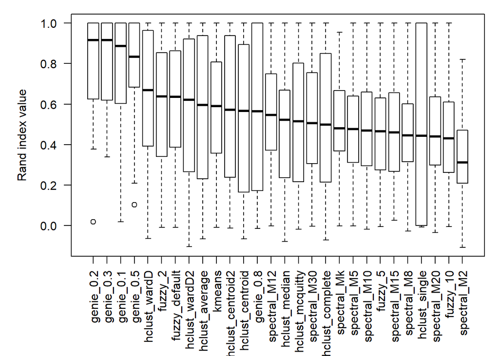

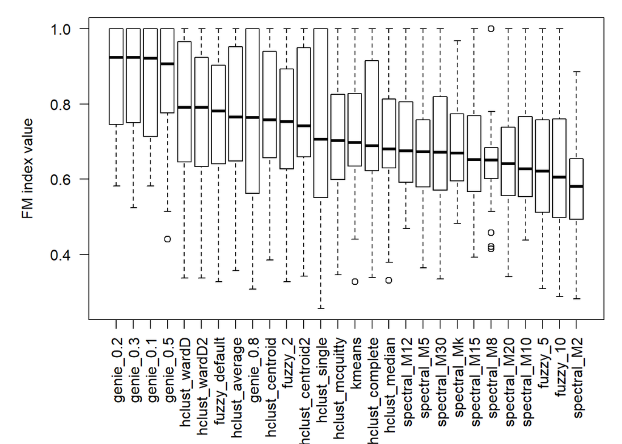

Płyną z nich kolejne wnioski:

- Po raz kolejny algorytmy *gini* wyraźnie wyróżniają się spośród reszty. Charakteryzuje je również bardzo wysoka mediana - przeciętny znaleziony wynik jest wyjątkowo dobry i często okaże się lepszy od algorytmu, który na danym zbiorze danych działa dużo lepiej niż zwykle.
- Najdłuższe słupki na wykresie odpowiadają wcześniej zidentyfikowanym “specjalistom”, a najkrótsze - algorytmom uniwersalnym.
- Algorytm *spectral_Mk*, pomimo generalnie dobrego działania, nigdy nie zwraca rozwiązać poprawnych lub bardzo zbliżonych według indeksu Randa.